# Méthodes SVD et données électorales

Authors

Léon Lafosse

Mick Wanderly Laveus

# 1 I. Pipeline d’extraction des données

Les données sont récupérées depuis les **portails open data** français (opendata.paris.fr, data.gouv.fr). On s’appuie sur un fichier **informations_dataset.csv** qui centralise les métadonnées de chaque jeu de données : l’URL de téléchargement, le nom du fichier et son extension. Le téléchargement se fait via le package `httr`, et on stocke tout en local dans un dossier dédié.

# 2 II. Pipeline de nettoyage des données

Avant de pouvoir analyser quoi que ce soit, il faut mettre les données en forme. Les fichiers bruts téléchargés sont hétérogènes : formats différents, noms de colonnes incohérents d’une élection à l’autre, valeurs manquantes.

On applique les étapes suivantes :

- Conversion des fichiers **.txt** / **.csv** en **.parquet** (plus léger et plus rapide à charger).
- Suppression des lignes avec des valeurs manquantes.
- Renommage des colonnes pour avoir un schéma cohérent sur tous les jeux de données (`code_dep`, `code_com`, `bureau_vote`).
- Passage en **format wide** : une ligne = un bureau de vote, une colonne = un candidat ou une liste.

Un point d’attention : certains partis ont changé de nom au fil des années : le FN est devenu le RN en 2018, plusieurs mouvements de gauche se sont regroupés sous différentes étiquettes. Ces changements de nuances compliquent les comparaisons inter-élections, en particulier pour la partie régression.

## 2.1 Aperçu des données après nettoyage

Voici un aperçu des quatre jeux de données une fois nettoyés et mis au format wide. Chaque ligne correspond à un bureau de vote, identifié par `code_dep`, `code_com` et `bureau_vote`. Les colonnes suivantes donnent le nombre de voix (ou le pourcentage, selon le jeu de données) par liste ou nuance.

**Européennes 2009 — Paris** (850 bureaux, 27 listes)

| code_dep | code_com | bureau_vote | jean_michel_dubois | farid_ghehioueche | jean_marie_julia | gaspard_delanoe | rolande_perlican | sabine_herold | patrick_cosseron_de_villenoisy | alain_mourguy | jean_marc_governatori | elisabeth_barbay | axel_de_boer | daniel_cohn_bendit | michel_barnier | jean_pierre_enjalbert | omar_slaouti | annick_du_roscoat | jean_pierre_mercier | jean_luc_pasquinet | dieudonne_mbala_mbala | alain_ducq | jerome_riviere | andre_locussol | francoise_castany | patrick_le_hyaric | marianne_ranke_cormier | harlem_desir | marielle_de_sarnez |
| --- | --- | --- | --- | --- | --- | --- | --- | --- | --- | --- | --- | --- | --- | --- | --- | --- | --- | --- | --- | --- | --- | --- | --- | --- | --- | --- | --- | --- | --- |
| 3 | 12 | 9 | 17 | 0 | 2 | 2 | 0 | 1 | 0 | 0 | 19 | 1 | 5 | 279 | 173 | 5 | 18 | 3 | 3 | 0 | 7 | 0 | 12 | 0 | 5 | 40 | 1 | 143 | 61 |
| 5 | 19 | 5 | 8 | 1 | 1 | 0 | 0 | 3 | 0 | 0 | 9 | 1 | 0 | 276 | 245 | 10 | 16 | 0 | 0 | 0 | 4 | 0 | 20 | 1 | 6 | 51 | 1 | 119 | 57 |
| 6 | 24 | 7 | 9 | 3 | 1 | 0 | 0 | 1 | 0 | 0 | 5 | 0 | 0 | 128 | 221 | 7 | 11 | 2 | 0 | 0 | 5 | 0 | 14 | 0 | 3 | 9 | 0 | 69 | 49 |
| 7 | 25 | 8 | 15 | 0 | 0 | 0 | 0 | 1 | 0 | 0 | 7 | 0 | 2 | 145 | 428 | 18 | 6 | 3 | 0 | 0 | 2 | 0 | 44 | 1 | 4 | 8 | 0 | 54 | 64 |
| 7 | 28 | 18 | 30 | 0 | 0 | 0 | 0 | 1 | 0 | 0 | 5 | 1 | 0 | 89 | 313 | 14 | 2 | 1 | 1 | 1 | 3 | 0 | 22 | 1 | 4 | 11 | 0 | 56 | 61 |

**Européennes 2024 — Paris** (902 bureaux, 38 listes)

| code_dep | code_com | bureau_vote | deher_lesaint_leopold_edouard | ponge_philippe | marechal_marion | aubry_manon | bardella_jordan | toussaint_marie | azergui_nagib | thouy_helene | terrien_olivier | zorn_caroline | hayer_valerie | alexandre_audric | cholley_marine | wehrling_yann | asselineau_francois | simonin_michel | fortane_jean_marc | bellamy_francois_xavier | arthaud_nathalie | larrouturou_pierre | renard_kuzmanovic_georges | labib_selma | adoue_camille | philippot_florian | husson_edouard | bonneau_pierre_marie | glucksmann_raphael | … |
| --- | --- | --- | --- | --- | --- | --- | --- | --- | --- | --- | --- | --- | --- | --- | --- | --- | --- | --- | --- | --- | --- | --- | --- | --- | --- | --- | --- | --- | --- | --- |
| 1 | 4 | 9 | 0 | 0 | 64 | 43 | 44 | 28 | 0 | 13 | 0 | 2 | 162 | 0 | 4 | 2 | 4 | 0 | 0 | 109 | 0 | 0 | 0 | 0 | 0 | 3 | 0 | 0 | 91 | … |
| 3 | 10 | 26 | 0 | 0 | 47 | 94 | 67 | 128 | 0 | 9 | 0 | 3 | 180 | 2 | 6 | 4 | 4 | 0 | 0 | 85 | 2 | 1 | 1 | 2 | 0 | 1 | 0 | 0 | 291 | … |
| 3 | 9 | 34 | 0 | 0 | 58 | 113 | 47 | 177 | 0 | 14 | 0 | 3 | 232 | 0 | 5 | 1 | 3 | 0 | 0 | 56 | 2 | 2 | 0 | 1 | 0 | 7 | 0 | 0 | 340 | … |
| 6 | 24 | 8 | 0 | 0 | 33 | 40 | 55 | 43 | 0 | 4 | 0 | 2 | 191 | 0 | 1 | 1 | 1 | 0 | 0 | 105 | 0 | 0 | 0 | 0 | 0 | 4 | 0 | 0 | 136 | … |
| 7 | 27 | 10 | 0 | 0 | 103 | 71 | 104 | 63 | 0 | 12 | 0 | 3 | 263 | 0 | 4 | 0 | 5 | 0 | 0 | 155 | 0 | 0 | 0 | 0 | 0 | 18 | 0 | 0 | 167 | … |

**Législatives 2017 T1 — national** (45822 bureaux, 17 nuances)

| code_dep | code_com | bureau_vote | inscrits | votants | COM | DIV | DLF | ECO | EXG | FI | FN | LR | REM | SOC | DVG | MDM | RDG | UDI | DVD | EXD | REG |
| --- | --- | --- | --- | --- | --- | --- | --- | --- | --- | --- | --- | --- | --- | --- | --- | --- | --- | --- | --- | --- | --- |
| 01 | 002 | 0001 | 211 | 132 | 1 | 4 | 0 | 15 | 2 | 14 | 18 | 39 | 32 | 3 | 0 | 0 | 0 | 0 | 0 | 0 | 0 |
| 01 | 004 | 0001 | 1126 | 489 | 12 | 17 | 7 | 9 | 2 | 79 | 86 | 118 | 126 | 20 | 0 | 0 | 0 | 0 | 0 | 0 | 0 |
| 01 | 004 | 0002 | 1134 | 555 | 12 | 24 | 8 | 9 | 4 | 79 | 101 | 129 | 144 | 31 | 0 | 0 | 0 | 0 | 0 | 0 | 0 |
| 01 | 004 | 0006 | 1116 | 557 | 13 | 13 | 9 | 19 | 5 | 74 | 74 | 170 | 154 | 19 | 0 | 0 | 0 | 0 | 0 | 0 | 0 |
| 01 | 004 | 0007 | 1056 | 496 | 7 | 20 | 7 | 22 | 2 | 67 | 77 | 120 | 156 | 12 | 0 | 0 | 0 | 0 | 0 | 0 | 0 |

**Législatives 2022 T1 — national** (66387 bureaux, 16 nuances)

| code_dep | code_com | bureau_vote | inscrits | votants | DSV | DVC | DVD | DVG | DXG | ECO | ENS | LR | NUP | RDG | REC | RN | DIV | REG | UDI | DXD |
| --- | --- | --- | --- | --- | --- | --- | --- | --- | --- | --- | --- | --- | --- | --- | --- | --- | --- | --- | --- | --- |
| 01 | 01001 | 1 | 644 | 343 | 5 | 33 | 4 | 0 | 4 | 8 | 50 | 59 | 52 | 16 | 21 | 87 | 0 | 0 | 0 | 0 |
| 01 | 01002 | 1 | 218 | 133 | 3 | 0 | 53 | 0 | 4 | 0 | 0 | 14 | 44 | 0 | 2 | 8 | 0 | 0 | 0 | 0 |
| 01 | 01004 | 1 | 1134 | 470 | 5 | 0 | 108 | 8 | 9 | 0 | 0 | 54 | 133 | 0 | 20 | 115 | 9 | 0 | 0 | 0 |
| 01 | 01004 | 2 | 1141 | 516 | 4 | 0 | 159 | 5 | 9 | 0 | 0 | 36 | 144 | 0 | 29 | 108 | 10 | 0 | 0 | 0 |
| 01 | 01004 | 3 | 1211 | 615 | 11 | 0 | 176 | 4 | 10 | 0 | 0 | 54 | 183 | 0 | 37 | 112 | 7 | 0 | 0 | 0 |

# 3 III. Factorisation matricielle (ACP / SVD)

Pour chaque tour d’élection, les données se présentent sous forme d’un tableau où les **lignes** sont les bureaux de vote et les **colonnes** le nombre de voix obtenus par chaque liste ou candidat. On centre et réduit ce tableau avant d’appliquer une **ACP** : ce qui revient à faire une SVD de la matrice centrée-réduite : pour identifier les principaux axes de variation politique entre les bureaux. Cela permet de visualiser plus facilement les tendances politiques et de repérer les bureaux de vote qui ont des comportements similaires.

## 3.1 ACP, Européennes 2009 (Paris)

On commence par les européennes de 2009 à Paris. Après centrage-réduction, on applique `prcomp()` sur la matrice des votes.

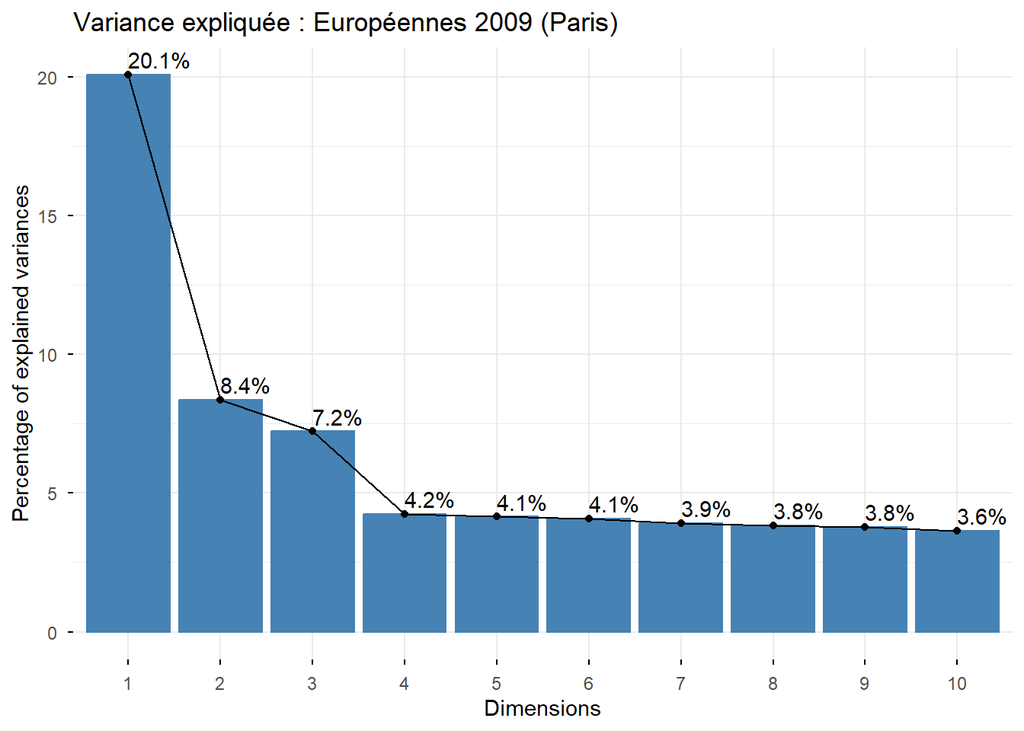

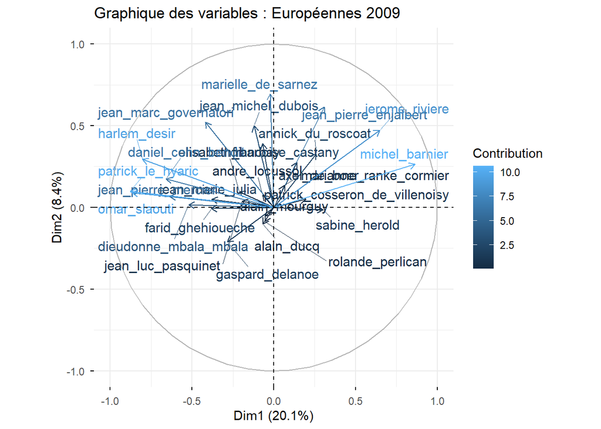

Ce graphique permet de voir comment les partis se regroupent dans les bureaux de vote parisiens. L’analyse des variables montre que la Dim1 (PC1) sépare les bureaux de vote selon leur soutien aux listes de gauche (PS, Verts, Front de Gauche), qui tirent fortement vers la gauche du graphique. La Dim2 (PC2) illustre une opposition entre le centre (MoDem), qui tire vers le haut, et les autres formations politiques. Les flèches courtes proches du centre représentent des listes ayant eu peu d’influence sur la structure globale des votes à Paris en 2009.

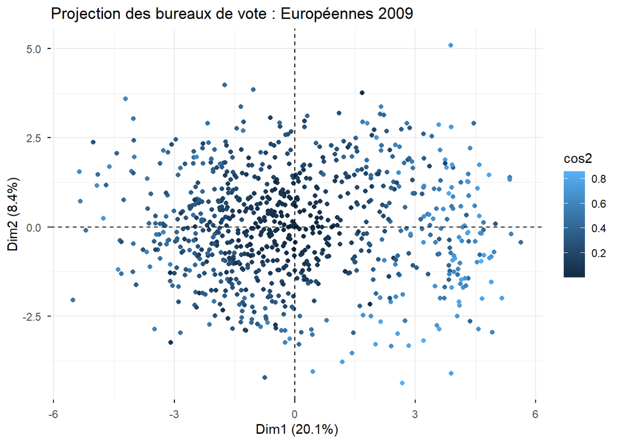

## 3.2 ACP : Européennes 2024 (Paris)

On refait la même analyse pour les européennes de 2024. Le paysage politique a pas mal évolué en quinze ans, montée en puissance du RN, recomposition à gauche, ce qui devrait se refléter dans la structure des composantes.

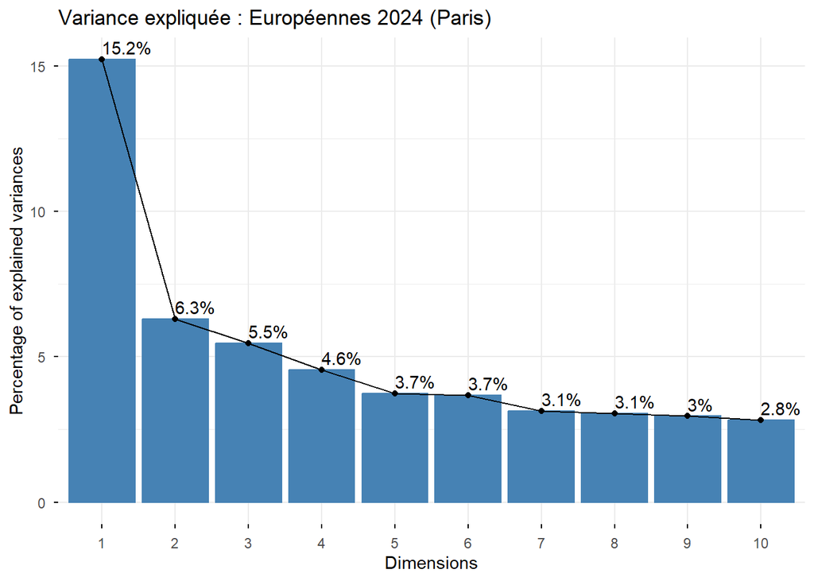

En 2024, PC1 n’explique plus que 15,2% contre 20,1% en 2009. Cela s’explique surtout par le nombre bien plus grand de listes en 2024, qui répartit la variance sur beaucoup plus de dimensions.

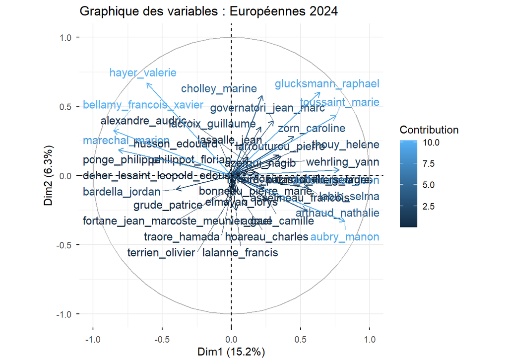

Le graphique est plus chargé qu’en 2009 du fait du nombre de listes. Sur Dim1, on distingue deux groupes opposés : à gauche `bardella_jordan` et `marechal_marion`, à droite `glucksmann_raphael` et `toussaint_marie`. Sur Dim2, `hayer_valerie` se démarque clairement vers le haut.

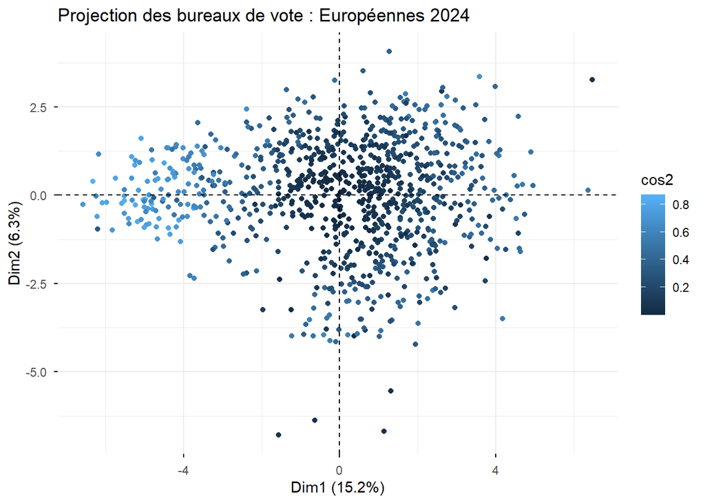

## 3.3 Comparaison 2009 / 2024 par SVD inter-élections

Pour comparer directement les structures de vote entre 2009 et 2024, on calcule la **matrice de covariance croisée** entre les deux tableaux centrés-réduits, restreints aux bureaux présents dans les deux élections, puis on en fait la SVD. Les valeurs singulières mesurent dans quelle mesure les deux élections co-varient dans chaque direction, autrement dit, si les bureaux qui votaient d’une certaine façon en 2009 continuent à le faire en 2024.

```
Bureaux communs : 475
```

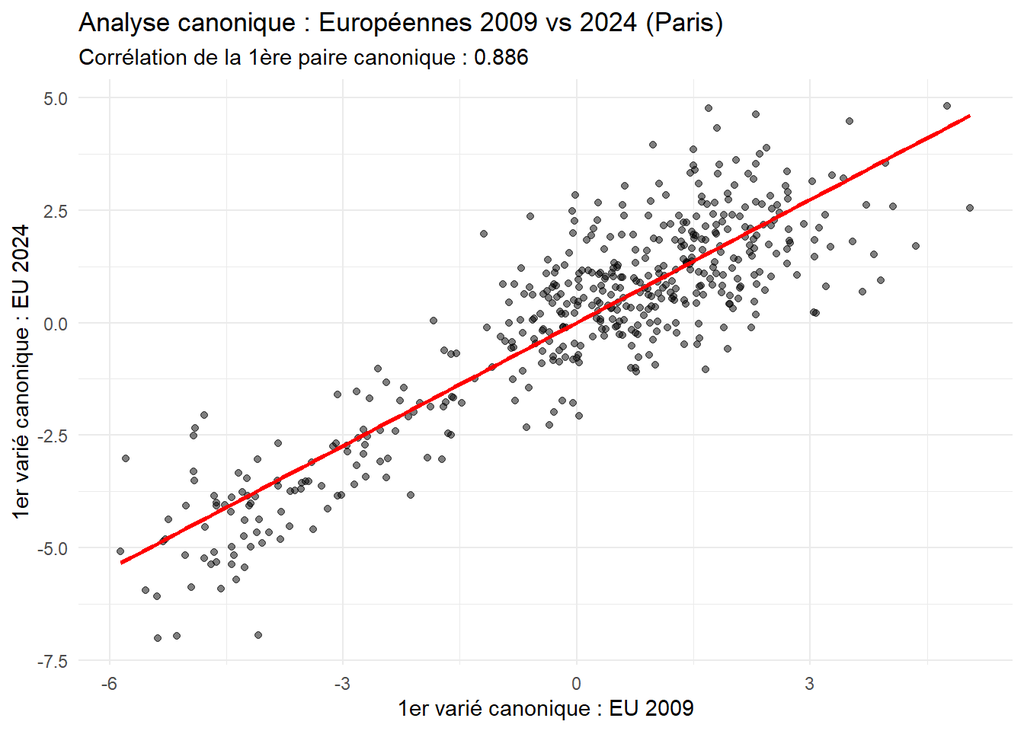

La corrélation élevée entre les premiers variés canoniques montre que le **principal axe de variation politique à Paris est resté stable entre 2009 et 2024**, malgré les recompositions partisanes. Les bureaux qui votaient fortement à droite en 2009 continuent globalement à le faire en 2024, et inversement. Les quelques bureaux qui s’écartent de la droite rouge sont ceux dont le profil a le plus changé entre les deux élections.

# 4 IV. Clustering

On cherche maintenant à regrouper les bureaux de vote selon leur profil de vote. On travaille sur les coordonnées des 5 premières composantes principales issues de l’ACP sur les européennes 2024, ce qui permet de réduire le bruit tout en conservant l’essentiel de l’information.

## 4.1 Choix du nombre de clusters

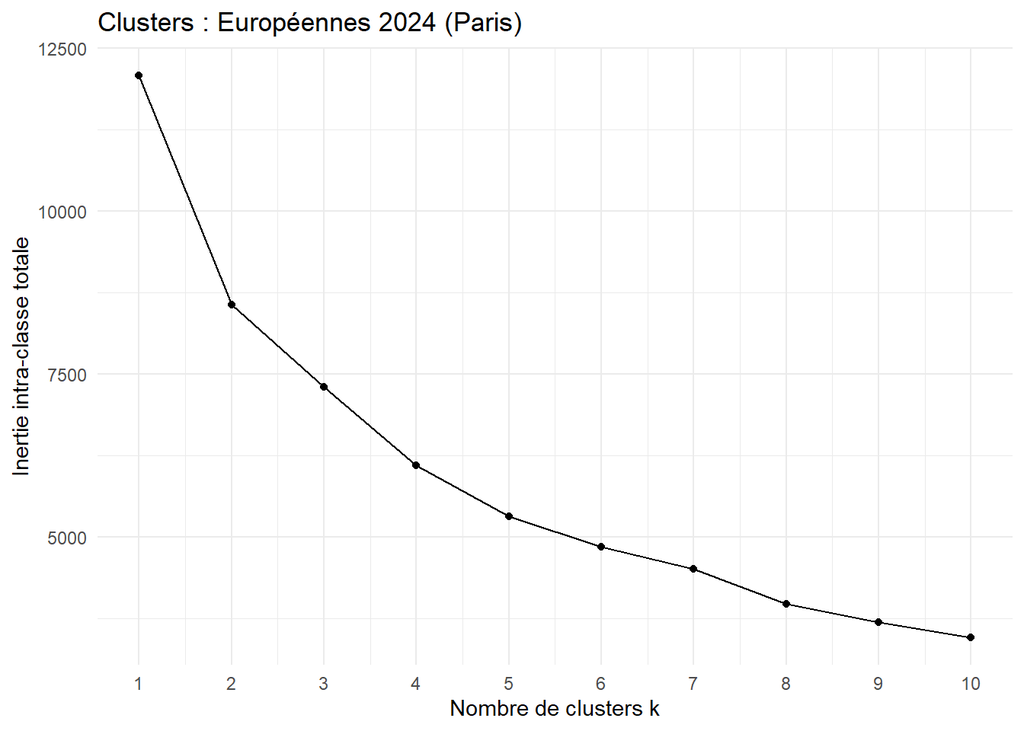

## 4.2 Critère de silhouette

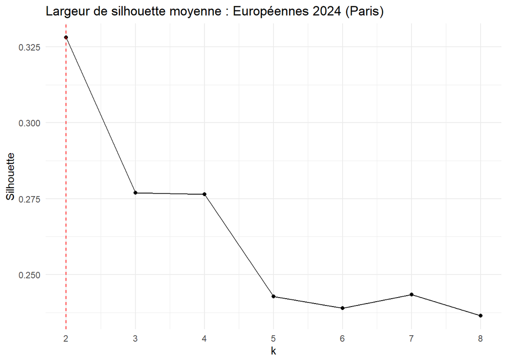

La silhouette identifie **k = 2** comme la partition la plus cohérente.

## 4.3 K-means

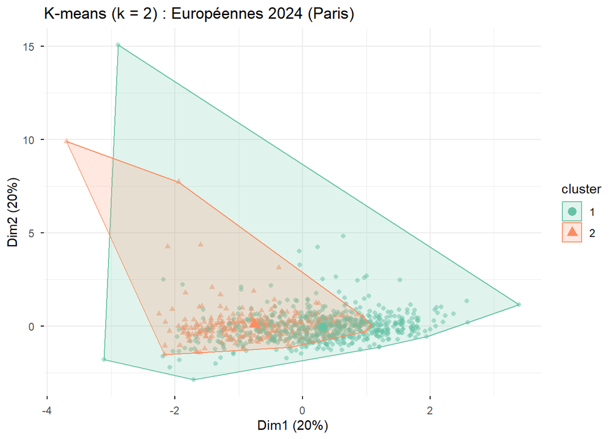

```
  cluster size ave.sil.width
1       1  633          0.31
2       2  269          0.37
```

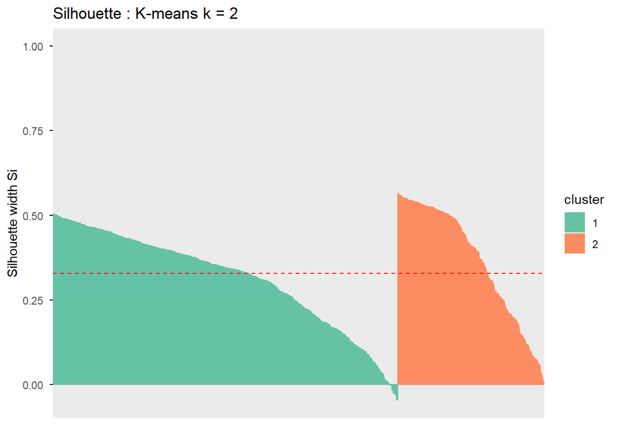

## 4.4 Clustering hiérarchique (Ward D2)

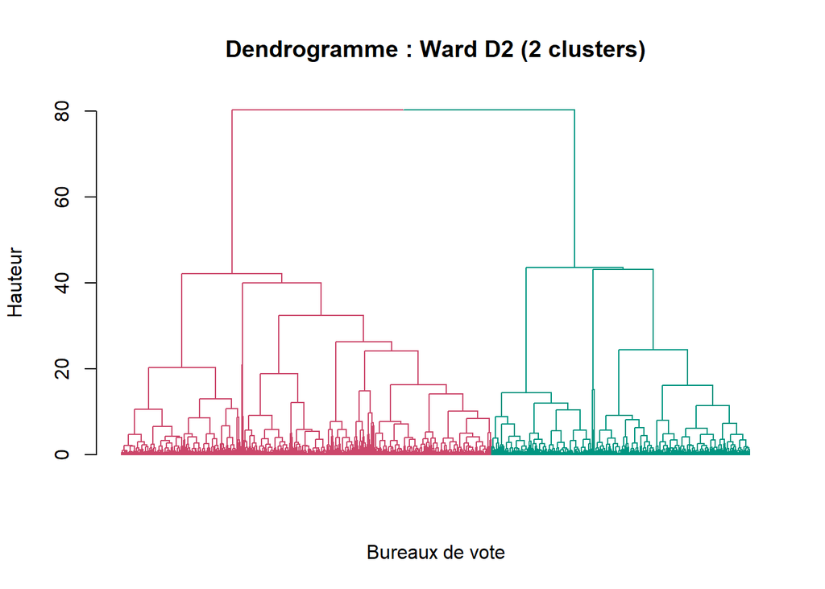

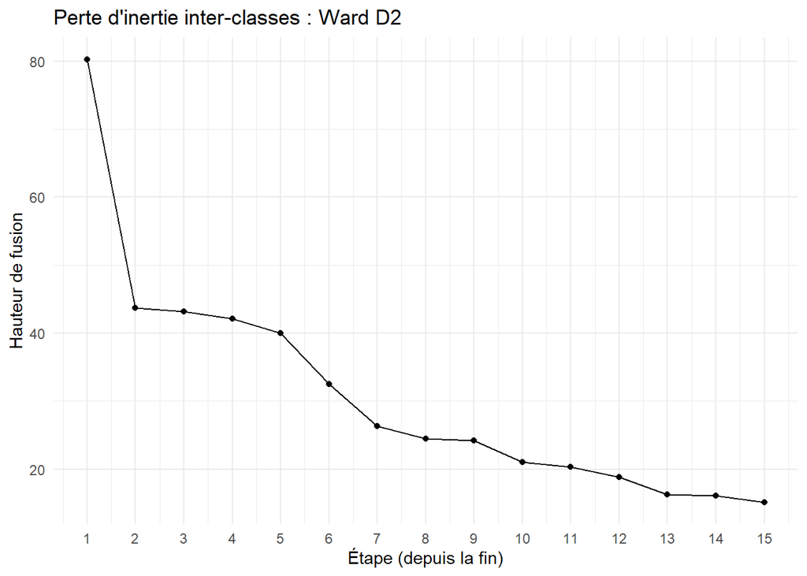

## 4.5 Comparaison Ward D2 vs Complete linkage

```
    Complete
Ward   1   2
   1 369   2
   2 531   0
```

Le tableau croisé montre dans quelle mesure les deux partitions concordent. Ward D2 produit des groupes plus compacts et mieux équilibrés que le lien complet, qui a tendance à créer un gros cluster et quelques petits satellites.

# 5 V. Régression linéaire

## 5.1 Présentation du modèle

L’objectif est de mesurer la **stabilité géographique du vote** : un bureau qui vote fortement pour une tendance en 2017 continue-t-il à le faire en 2022 ?

On joint les deux tables législatives sur le triplet `(code_dep, code_com, bureau_vote)`. Chaque ligne de la table résultante correspond à un bureau de vote. Les colonnes suffixées `_lg17` sont les **variables explicatives** (scores 2017 en % des inscrits), les colonnes sans suffixe sont les **variables réponse** (scores 2022 en % des inscrits).

```
Bureaux de vote disponibles : 44821
```

```
Nuances 2017 (variables explicatives) : 17
```

```
Nuances 2022 (variables réponse) : 16
```

Aperçu de la table jointe (44821 bureaux, 17 prédicteurs `_lg17`, 16 variables réponse). Seules quelques colonnes sont affichées pour la lisibilité :

| code_dep | code_com | bureau_vote | COM_lg17 | DIV_lg17 | DLF_lg17 | DSV | DVC | DVD |
| --- | --- | --- | --- | --- | --- | --- | --- | --- |
| 1 | 2 | 1 | 0.4739336 | 1.895735 | 0.0000000 | 1.3761468 | 0 | 24.31193 |
| 1 | 4 | 1 | 1.0657194 | 1.509769 | 0.6216696 | 0.4409171 | 0 | 9.52381 |
| 1 | 4 | 2 | 1.0582011 | 2.116402 | 0.7054674 | 0.3505697 | 0 | 13.93514 |
| 1 | 4 | 6 | 1.1648746 | 1.164875 | 0.8064516 | 0.3442341 | 0 | 13.85542 |
| 1 | 4 | 7 | 0.6628788 | 1.893939 | 0.6628788 | 0.3883495 | 0 | 16.11650 |

### 5.1.1 Formulation

Pour chaque nuance $k$ de 2022, on ajuste un modèle de régression linéaire multiple en utilisant les scores de toutes les nuances de 2017 comme prédicteurs :

$$y_{ik} = \beta_0^{(k)} + \sum_{j=1}^{p} \beta_j^{(k)} \, x_{ij} + \varepsilon_{ik}$$

où $y_{ik}$ est le pourcentage de voix pour la nuance $k$ en 2022 au bureau $i$, $x_{ij}$ le pourcentage de voix pour la nuance $j$ en 2017, et $\varepsilon_{ik}$ le résidu. En notation matricielle, avec $X \in \mathbb{R}^{n \times (p+1)}$ la matrice des prédicteurs augmentée d’une colonne de 1 :

$$y_k = X \, \beta^{(k)} + \varepsilon^{(k)}, \qquad \hat{\beta}^{(k)} = (X^T X)^{-1} X^T y_k$$

On évalue chaque modèle sur l’ensemble test (20 % des bureaux, jamais vus à l’entraînement) via :

$$\text{RMSE} = \sqrt{\frac{1}{n_{test}} \sum_{i} (y_{ik} - \hat{y}_{ik})^2} \qquad R^2 = 1 - \frac{\sum_{i}(y_{ik} - \hat{y}_{ik})^2}{\sum_{i}(y_{ik} - \bar{y}_k)^2}$$

## 5.2 Régression par nuance

| nuance | RMSE | R2 |
| --- | --- | --- |
| DSV | 0.869 | 0.260 |
| DVC | 1.565 | 0.029 |
| DVD | 4.041 | 0.115 |
| DVG | 3.028 | 0.150 |
| DXG | 0.551 | 0.098 |
| ECO | 1.121 | 0.060 |
| ENS | 4.388 | 0.461 |
| LR | 5.017 | 0.388 |
| NUP | 3.854 | 0.576 |
| RDG | 1.136 | 0.058 |
| REC | 1.485 | 0.091 |
| RN | 3.475 | 0.617 |
| DIV | 1.097 | 0.084 |
| REG | 0.997 | 0.313 |
| UDI | 1.793 | 0.053 |
| DXD | 0.134 | 0.003 |

Chaque ligne du tableau correspond à un modèle distinct : on prédit le score de la nuance $k$ en 2022 à partir de l’ensemble des scores de 2017. Un $R^2$ élevé indique que la géographie du vote pour cette nuance est restée stable entre les deux scrutins ; un $R^2$ faible signale au contraire une recomposition politique importante que le passé ne permettait pas d’anticiper.

## 5.3 Visualisation prédit vs observé

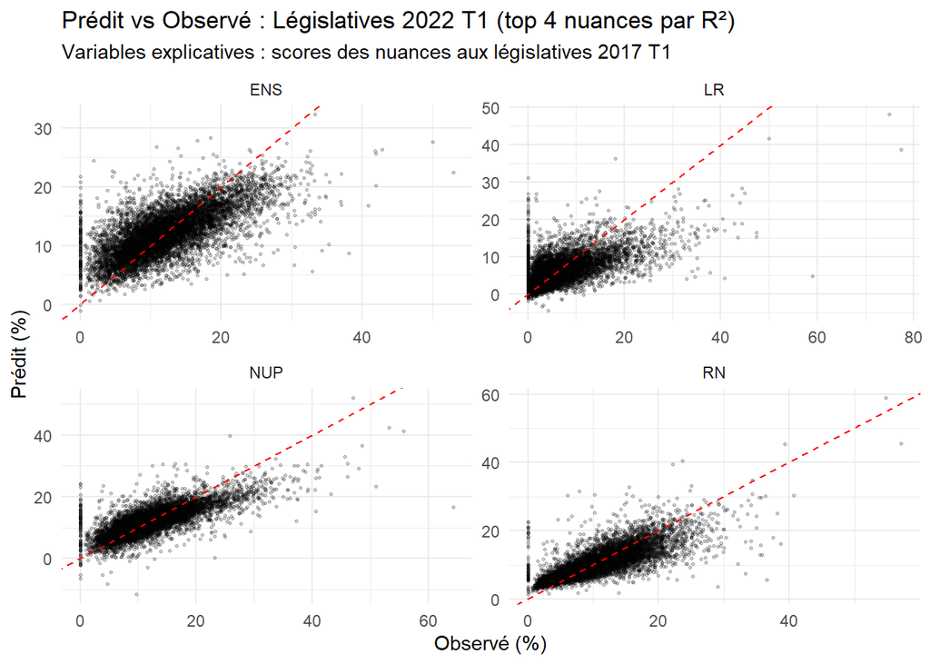

Pour chacune des 4 nuances les mieux prédites, on compare les valeurs observées en 2022 (axe horizontal) aux valeurs prédites par le modèle (axe vertical). La droite rouge en pointillés représente la prédiction parfaite ($\hat{y} = y$). Plus les points noirs s’alignent sur cette diagonale, plus le vote 2022 est le miroir fidèle du vote 2017. Les points qui s’en écartent correspondent à des bureaux où il y a eu un changement que le passé ne permettait pas d’anticiper : effet d’un nouveau candidat local, recomposition d’alliances, ou mobilisation différentielle de l’électorat.

# 6 Annexe

## 6.1 Code R

```r
stopifnot(
  require(tidyverse),
  require(dplyr),
  require(tidyr),
  require(ggplot2),
  require(plotly),
  require(arrow),
  require(httr),
  require(jsonlite),
  require(tools),
  require(FactoMineR),
  require(factoextra),
  require(cluster),
  require(dendextend),
  require(broom)
)
path_download <- "./DATA/downloaded_dataset/"
path_cleaned  <- "./DATA/cleaned_dataset/"
# Téléchargement des jeux de données depuis les portails open data
df_info <- read.csv("./DATA/informations_dataset.csv", header = TRUE)
df_info <- df_info[!is.na(df_info$extension) & df_info$extension != "", ]

for (i in 1:nrow(df_info)) {
  url       <- df_info$url[i]
  file_name <- df_info$file_name[i]
  extension <- df_info$extension[i]
  dest_file <- paste0(path_download, file_name, ".", extension)
  requete   <- httr::GET(url, write_disk(dest_file, overwrite = TRUE))
  stop_for_status(requete)
}
# Conversion txt/csv -> parquet
df_info <- read.csv("./DATA/informations_dataset.csv", header = TRUE)
df_info <- df_info[!is.na(df_info$extension) & df_info$extension != "", ]

for (i in 1:nrow(df_info)) {
  file_name <- df_info$file_name[i]
  extension <- df_info$extension[i]
  file_src  <- paste0(path_download, file_name, ".", extension)
  file_dest <- paste0(path_download, file_name, ".parquet")

  if (extension %in% c("csv", "txt")) {
    df <- read.csv(file_src, sep = ";")
    write_parquet(df, file_dest)
    rm(df)
  }
}
# Suppression des lignes contenant des NA (fichiers parquet uniquement)
for (file_name in list.files(path_download)) {
  if (tools::file_ext(file_name) == "parquet") {
    fp <- paste0(path_download, file_name)
    df <- read_parquet(fp)
    df <- na.omit(df)
    write_parquet(df, fp)
    rm(df)
  }
}
# ── Européennes 2009 - Paris (déjà en format wide) ──────────────────────────
df_eu2009 <- read_parquet(paste0(path_download, "elections_europeennes_2009_t1.parquet"))

meta_cols_09 <- c("id_bvote","scrutin","annee","tour","date","num_circ",
                  "num_quartier","num_arrond","num_bureau",
                  "nb_procu","nb_inscr","nb_emarg","nb_votant","nb_bl_nul","nb_exprim")
cands_2009 <- setdiff(colnames(df_eu2009), meta_cols_09)

df_eu2009 |>
  select(num_arrond, num_quartier, num_bureau, all_of(cands_2009)) |>
  rename(code_dep = num_arrond, code_com = num_quartier, bureau_vote = num_bureau) |>
  na.omit() |>
  write_parquet(paste0(path_cleaned, "eu2009.parquet"))

# ── Européennes 2019 - Paris (format wide) ───────────────────────────────────
df_eu2019 <- read_parquet(paste0(path_download, "elections_europeennes_2019_t1.parquet"))

meta_cols_19 <- c("id_bvote","scrutin","annee","tour","date","num_circ",
                  "num_quartier","num_arrond","num_bureau",
                  "nb_procu","nb_inscr","nb_emarg","nb_votant","nb_bl_nul","nb_exprim")
cands_2019 <- setdiff(colnames(df_eu2019), meta_cols_19)

df_eu2019 |>
  select(num_arrond, num_quartier, num_bureau, all_of(cands_2019)) |>
  rename(code_dep = num_arrond, code_com = num_quartier, bureau_vote = num_bureau) |>
  na.omit() |>
  write_parquet(paste0(path_cleaned, "eu2019.parquet"))

# ── Européennes 2024 - Paris (format wide) ───────────────────────────────────
df_eu2024 <- read_parquet(paste0(path_download, "elections_europeennes_2024_t1.parquet"))

meta_cols_24 <- c("objectid","id_bv","scrutin","annee","tour","date",
                  "num_circ","num_quartier","num_arrond","num_bureau",
                  "nb_procu","nb_inscr","nb_emarg","nb_votant",
                  "nb_bl","nb_nul","nb_exprim",
                  "st_area_shape","st_perimeter_shape","geo_shape","geo_point_2d")
cands_2024 <- setdiff(colnames(df_eu2024), meta_cols_24)

df_eu2024 |>
  select(num_arrond, num_quartier, num_bureau, all_of(cands_2024)) |>
  rename(code_dep = num_arrond, code_com = num_quartier, bureau_vote = num_bureau) |>
  na.omit() |>
  write_parquet(paste0(path_cleaned, "eu2024.parquet"))

# ── Législatives 2017 T1 - national (long -> wide par nuance) ────────────────
read_parquet(paste0(path_download, "elections_legislatives_2017_t1.parquet")) |>
  select(code_du_departement, code_de_la_commune, code_du_b_vote,
         inscrits, votants, nuance, voix) |>
  rename(code_dep = code_du_departement,
         code_com = code_de_la_commune,
         bureau_vote = code_du_b_vote) |>
  group_by(code_dep, code_com, bureau_vote, inscrits, votants, nuance) |>
  summarise(voix = sum(voix, na.rm = TRUE), .groups = "drop") |>
  pivot_wider(names_from = nuance, values_from = voix, values_fill = 0) |>
  na.omit() |>
  write_parquet(paste0(path_cleaned, "lg2017_t1.parquet"))

# ── Législatives 2022 T1 - national (long -> wide par nuance) ────────────────
read_parquet(paste0(path_download, "elections_legislatives_2022_t1.parquet")) |>
  select(dep_code, com_code, code_du_b_vote,
         inscrits, votants, nuance, voix) |>
  rename(code_dep = dep_code,
         code_com = com_code,
         bureau_vote = code_du_b_vote) |>
  group_by(code_dep, code_com, bureau_vote, inscrits, votants, nuance) |>
  summarise(voix = sum(voix, na.rm = TRUE), .groups = "drop") |>
  pivot_wider(names_from = nuance, values_from = voix, values_fill = 0) |>
  na.omit() |>
  write_parquet(paste0(path_cleaned, "lg2022_t1.parquet"))
# Chargement des jeux de données nettoyés
eu2009 <- read_parquet(paste0(path_cleaned, "eu2009.parquet"))
eu2024 <- read_parquet(paste0(path_cleaned, "eu2024.parquet"))
lg2017 <- read_parquet(paste0(path_cleaned, "lg2017_t1.parquet"))
lg2022 <- read_parquet(paste0(path_cleaned, "lg2022_t1.parquet"))
head(eu2009, 5)
head(eu2024, 5)
head(lg2017, 5)
head(lg2022, 5)
X_2009    <- eu2009 |> select(-code_dep, -code_com, -bureau_vote)
X_2009_sc <- scale(X_2009)
pca_2009  <- prcomp(X_2009_sc, center = FALSE, scale. = FALSE)
fviz_screeplot(pca_2009, addlabels = TRUE) +
  labs(title = "Variance expliquée : Européennes 2009 (Paris)")
fviz_pca_var(pca_2009, col.var = "contrib", repel = TRUE) +
  labs(title = "Graphique des variables : Européennes 2009",
       color = "Contribution")
fviz_pca_ind(pca_2009, geom = "point", col.ind = "cos2", repel = FALSE) +
  labs(title = "Projection des bureaux de vote : Européennes 2009")
X_2024    <- eu2024 |> select(-code_dep, -code_com, -bureau_vote)
X_2024_sc <- scale(X_2024)
pca_2024  <- prcomp(X_2024_sc, center = FALSE, scale. = FALSE)
fviz_screeplot(pca_2024, addlabels = TRUE) +
  labs(title = "Variance expliquée : Européennes 2024 (Paris)")
fviz_pca_var(pca_2024, col.var = "contrib", repel = TRUE) +
  labs(title = "Graphique des variables : Européennes 2024",
       color = "Contribution")
fviz_pca_ind(pca_2024, geom = "point", col.ind = "cos2", repel = FALSE) +
  labs(title = "Projection des bureaux de vote : Européennes 2024")
key_2009  <- paste(eu2009$code_dep, eu2009$code_com, eu2009$bureau_vote)
key_2024  <- paste(eu2024$code_dep, eu2024$code_com, eu2024$bureau_vote)
common_bv <- intersect(key_2009, key_2024)
```

```r
eu2009_cca <- eu2009 |>
  filter(paste(code_dep, code_com, bureau_vote) %in% common_bv) |>
  arrange(code_dep, code_com, bureau_vote) |>
  select(-code_dep, -code_com, -bureau_vote)

eu2024_cca <- eu2024 |>
  filter(paste(code_dep, code_com, bureau_vote) %in% common_bv) |>
  arrange(code_dep, code_com, bureau_vote) |>
  select(-code_dep, -code_com, -bureau_vote)

cat("Bureaux communs :", nrow(eu2009_cca), "\n")
Y1      <- scale(eu2009_cca)
Y2      <- scale(eu2024_cca)
C       <- t(Y1) %*% Y2 / (nrow(Y1) - 1)
svd_res <- svd(C)
z1 <- Y1 %*% svd_res$u[, 1]
z2 <- Y2 %*% svd_res$v[, 1]

df_cca <- data.frame(canon_2009 = as.numeric(z1),
                     canon_2024 = as.numeric(z2))

ggplot(df_cca, aes(x = canon_2009, y = canon_2024)) +
  geom_point(alpha = 0.5) +
  geom_smooth(method = "lm", color = "red", se = FALSE) +
  labs(title = "Analyse canonique : Européennes 2009 vs 2024 (Paris)",
       subtitle = paste0("Corrélation de la 1ère paire canonique : ",
                         round(cor(z1, z2), 3)),
       x = "1er varié canonique : EU 2009",
       y = "1er varié canonique : EU 2024") +
  theme_minimal()
coords_clust <- as.data.frame(pca_2024$x[, 1:5])

set.seed(123)
inertie <- sapply(1:10, function(k) {
  kmeans(coords_clust, centers = k, nstart = 25)$tot.withinss
})

data.frame(k = 1:10, inertie = inertie) |>
  ggplot(aes(x = k, y = inertie)) +
  geom_line() + geom_point() +
  scale_x_continuous(breaks = 1:10) +
  labs(title = "Clusters : Européennes 2024 (Paris)",
       x = "Nombre de clusters k",
       y = "Inertie intra-classe totale") +
  theme_minimal()
sil_scores <- sapply(2:8, function(k) {
  km <- kmeans(coords_clust, centers = k, nstart = 25)
  mean(silhouette(km$cluster, dist(coords_clust))[, 3])
})

k_opt <- (2:8)[which.max(sil_scores)]

data.frame(k = 2:8, silhouette = sil_scores) |>
  ggplot(aes(x = k, y = silhouette)) +
  geom_line() + geom_point() +
  geom_vline(xintercept = k_opt, linetype = "dashed", color = "red") +
  scale_x_continuous(breaks = 2:8) +
  labs(title = "Largeur de silhouette moyenne : Européennes 2024 (Paris)",
       x = "k", y = "Silhouette") +
  theme_minimal()
set.seed(42)
km <- kmeans(coords_clust, centers = k_opt, nstart = 50)

fviz_cluster(km,
             data = coords_clust,
             geom = "point",
             ellipse.type = "convex",
             palette = "Set2",
             alpha = 0.5,
             ggtheme = theme_minimal()) +
  labs(title = paste0("K-means (k = ", k_opt, ") : Européennes 2024 (Paris)"))
sil_km <- silhouette(km$cluster, dist(coords_clust))
fviz_silhouette(sil_km, palette = "Set2", ggtheme = theme_minimal()) +
  labs(title = paste0("Silhouette : K-means k = ", k_opt))
dist_mat <- dist(coords_clust, method = "euclidean")
hc_ward  <- hclust(dist_mat, method = "ward.D2")

dend <- color_branches(as.dendrogram(hc_ward), k = k_opt)
plot(dend,
     main = paste0("Dendrogramme : Ward D2 (", k_opt, " clusters)"),
     xlab = "Bureaux de vote", ylab = "Hauteur",
     leaflab = "none")
data.frame(step = 1:15, height = rev(hc_ward$height)[1:15]) |>
  ggplot(aes(x = step, y = height)) +
  geom_line() + geom_point() +
  scale_x_continuous(breaks = 1:15) +
  labs(title = "Perte d'inertie inter-classes : Ward D2",
       x = "Étape (depuis la fin)", y = "Hauteur de fusion") +
  theme_minimal()
hc_complete       <- hclust(dist_mat, method = "complete")
clusters_ward     <- cutree(hc_ward,     k = k_opt)
clusters_complete <- cutree(hc_complete, k = k_opt)

table(Ward = clusters_ward, Complete = clusters_complete)
nuances_17 <- setdiff(colnames(lg2017),
                      c("code_dep","code_com","bureau_vote","inscrits","votants"))
nuances_22 <- setdiff(colnames(lg2022),
                      c("code_dep","code_com","bureau_vote","inscrits","votants"))

clean_keys <- function(df) {
  df |> mutate(
    code_dep    = stringr::str_remove(as.character(code_dep),    "^0+"),
    code_com    = stringr::str_remove(stringr::str_sub(as.character(code_com), -3), "^0+"),
    bureau_vote = stringr::str_remove(as.character(bureau_vote), "^0+")
  )
}

X_17 <- lg2017 |>
  mutate(across(all_of(nuances_17), ~ . / pmax(inscrits, 1) * 100)) |>
  select(code_dep, code_com, bureau_vote, all_of(nuances_17)) |>
  clean_keys() |>
  rename_with(~ paste0(.x, "_lg17"), all_of(nuances_17))

Y_22 <- lg2022 |>
  mutate(across(all_of(nuances_22), ~ . / pmax(inscrits, 1) * 100)) |>
  select(code_dep, code_com, bureau_vote, all_of(nuances_22)) |>
  clean_keys()

df_reg <- inner_join(X_17, Y_22, by = c("code_dep","code_com","bureau_vote")) |>
  na.omit()

predictors <- paste0(nuances_17, "_lg17")
predictors <- predictors[predictors %in% colnames(df_reg)]

cat("Bureaux de vote disponibles :", nrow(df_reg), "\n")
cat("Nuances 2017 (variables explicatives) :", length(nuances_17), "\n")
cat("Nuances 2022 (variables réponse) :", length(nuances_22), "\n")
df_reg |>
  select(code_dep, code_com, bureau_vote,
         all_of(head(predictors, 3)),
         all_of(head(nuances_22, 3))) |>
  head(5)
set.seed(42)
n   <- nrow(df_reg)
idx <- sample(n, floor(0.8 * n))
train <- df_reg[idx, ]
test  <- df_reg[-idx, ]

rmse <- function(obs, pred) sqrt(mean((obs - pred)^2))
r2   <- function(obs, pred) 1 - sum((obs - pred)^2) / sum((obs - mean(obs))^2)

resultats <- map_dfr(nuances_22, function(nuance) {
  if (!nuance %in% colnames(train)) return(NULL)
  y_train <- train[[nuance]]
  y_test  <- test[[nuance]]
  if (sd(y_train, na.rm = TRUE) == 0) return(NULL)

  formula_str <- paste0("`", nuance, "` ~ ",
                        paste0("`", predictors, "`", collapse = " + "))
  mod  <- lm(as.formula(formula_str), data = train)
  pred <- predict(mod, newdata = test)

  data.frame(
    nuance = nuance,
    RMSE   = round(rmse(y_test, pred), 3),
    R2     = round(r2(y_test, pred),   3)
  )
})

resultats
top_nuances <- resultats |>
  filter(!is.na(R2)) |>
  arrange(desc(R2)) |>
  slice_head(n = 4) |>
  pull(nuance)

plot_data <- map_dfr(top_nuances, function(nuance) {
  formula_str <- paste0("`", nuance, "` ~ ",
                        paste0("`", predictors, "`", collapse = " + "))
  mod  <- lm(as.formula(formula_str), data = train)
  pred <- predict(mod, newdata = test)
  obs  <- test[[nuance]]
  data.frame(obs = obs, pred = pred, nuance = nuance)
})
```

```r
ggplot(plot_data, aes(x = obs, y = pred)) +
  geom_point(alpha = 0.2, size = 0.6) +
  geom_abline(slope = 1, intercept = 0, color = "red", linetype = "dashed") +
  facet_wrap(~nuance, scales = "free") +
  labs(title = "Prédit vs Observé : Législatives 2022 T1 (top 4 nuances par R²)",
       subtitle = "Variables explicatives : scores des nuances aux législatives 2017 T1",
       x = "Observé (%)", y = "Prédit (%)") +
  theme_minimal()
```